# Analyzing the Stroop Effect

**Alina Grigorescu**  
Bucharest, 2018

**INTRODUCTION**  
The study below analyses the results of a interference in the reaction time of a task.  
The task set was to say the color names of the ink (naming the color) in which words were written and the interference was that the words (that were color names) were colored differently than their word meaning. In psychology, this is called the **Stroop effect**.  
The situations when the color names were written in the same color as the word stated are called Congruent and the cases were there was a mismatch are called Incongruent. The time it took to name the colors in the two situations was measured in seconds.  
**QUESTIONS ANSWERED**  
In order to analyse the Stroop effect data we performed some **descriptive analysis** and a **dependent sample t-test** where the NULL Hypotheses(H0) states that the color of the text has has no effect on the reading time, while the ALTERNATIVE Hypotheses(H1) states that the color of the words has an influence on the time if reading the text. A **dependent sample t-test** was considered appropriate as the same participants are tested more than once and because the sample size is relatively small (only 24 participants/cases). The confidence level chosen was 99% (alpha=0.01).

**CONCLUSION**  
The **descriptive analysis** shows that the study contains 24 pairs of observations for Congruent and Incongruent reading time.  
The average time for reading congruent color names was 14 seconds, while for incongruent color names this was 22. The minimum difference in reading times was close to 2 seconds while the maximum difference was nearly 22 seconds. The standard deviation whithin the difference was 4.86 seconds. The results of the **dependent sample t-test** show that t_calculed of -8.02 is much lower than the t_critical established at question 2 (t_critical=-2.5). Thus, the t_calculated is in the critical region and the NULL hypothesis(H0) is rejected. This means that the difference in time to name the colors is statistically different in the case of congruence versus incongruence between ink color and word.

```python
# Render our plots inline
%matplotlib inline

import matplotlib.pyplot as plt
import pandas as pd
import numpy as np

# Read the file
stroopdata = pd.read_csv("stroopdata.csv")
```

```python
# Print content
print(stroopdata.sort_values(by='Incongruent', ascending=False))
```

```
    Congruent  Incongruent
14     18.200       35.255
19     12.369       34.288
9      14.480       26.282
16     18.495       25.139
6      14.692       24.572
10     22.328       24.524
20     12.944       23.894
4      14.669       22.803
15     12.130       22.158
22     19.710       22.058
2       9.564       21.214
23     16.004       21.157
5      12.238       20.878
8       9.401       20.762
17     10.639       20.429
13     16.929       20.330
0      12.079       19.278
1      16.791       18.741
11     15.298       18.644
21     14.233       17.960
12     15.073       17.510
18     11.344       17.425
7       8.987       17.394
3       8.630       15.687
```

```python
# Add difference between Congruent and Incongruent time to dataframe
stroopdata['Difference']=stroopdata['Incongruent']-stroopdata['Congruent']
print(stroopdata.sort_values(by='Difference', ascending=False))
```

```
    Congruent  Incongruent  Difference
19     12.369       34.288      21.919
14     18.200       35.255      17.055
9      14.480       26.282      11.802
2       9.564       21.214      11.650
8       9.401       20.762      11.361
20     12.944       23.894      10.950
15     12.130       22.158      10.028
6      14.692       24.572       9.880
17     10.639       20.429       9.790
5      12.238       20.878       8.640
7       8.987       17.394       8.407
4      14.669       22.803       8.134
0      12.079       19.278       7.199
3       8.630       15.687       7.057
16     18.495       25.139       6.644
18     11.344       17.425       6.081
23     16.004       21.157       5.153
21     14.233       17.960       3.727
13     16.929       20.330       3.401
11     15.298       18.644       3.346
12     15.073       17.510       2.437
22     19.710       22.058       2.348
10     22.328       24.524       2.196
1      16.791       18.741       1.950
```

The study contains 24 pairs of observations for Congruent and Incongruent reading time.  
The average time for reading congruent color names was 14 seconds, while for incongruent color names this was 22. The minimum difference in reading times was close to 2 seconds while the maximum difference was nearly 22 seconds. The standard deviation whithin the difference was 4.86 seconds.

(1) What is the independent variable? What is the dependent variable?  
**Independent variable**: The congruence/incongruence between the word and the color they are written in  
**Dependent variable**: The time it takes to read the words

(2) What is an appropriate set of hypotheses for this task? Specify your null and alternative hypotheses, and clearly define any notation used. Justify your choices.

H0: μi ≤ μc  
H1: μi > μc

Where:  
μc =time it takes to read the Congruent words  
μi =time it takes to read the Incongruent words  
In own words:  
**H0:** The time it takes to read the Congruent words (μc) is **higher or equal to** the time it takes to read the Incongruent words (μi)  
**H1**: The time it takes to read the Congruent words(μc) is **less** than the time it takes to read the Incongruent words (μi).  
The NULL Hypotheses(H0) states that the color of the text has has no effect on the reading time, while the ALTERNATIVE Hypotheses(H1) states that the color of the words has an influence on the time if reading the text.  
A **dependent sample t-test** will be performed. This is a statistical procedure used to determine whether the mean difference between two sets of observations is zero. In a dependent sample t-test (paired sample t-test), each subject or entity is measured twice, resulting in pairs of observations.  
The **dependent sample t-test** main assumptions:  
• The dependent variable must be continuous (in our case the time it takes to read the words).  
• The observations are independent of one another.  
• The dependent variable should be approximately normally distributed.  
• The dependent variable should not contain any outliers.  
For our data we have: • Confidence level 99% (alpha=0.01) • Degrees of freedom 23 (=24-1) • Resulting t_critical=-2.5

(3) Report some descriptive statistics regarding this dataset. Include at least one measure of central tendency and at least one measure of variability. The name of the data file is 'stroopdata.csv'.

Mean, Median, Standard Deviation, Variance

```python
# Show descriptive statistics
stroopdata.describe()
```

|  | Congruent | Incongruent | Difference |
| --- | --- | --- | --- |
| count | 24.000000 | 24.000000 | 24.000000 |
| mean | 14.051125 | 22.015917 | 7.964792 |
| std | 3.559358 | 4.797057 | 4.864827 |
| min | 8.630000 | 15.687000 | 1.950000 |
| 25% | 11.895250 | 18.716750 | 3.645500 |
| 50% | 14.356500 | 21.017500 | 7.666500 |
| 75% | 16.200750 | 24.051500 | 10.258500 |
| max | 22.328000 | 35.255000 | 21.919000 |

The study contains 24 pairs of observations for Congruent and Incongruent reading time.  
The average time for reading congruent color names was 14 seconds, while for incongruent color names this was 22. The minimum difference in reading times was close to 2 seconds while the maximum difference was nearly 22 seconds.  
The standard deviation whithin the difference was 4.86 seconds.

(4) Provide one or two visualizations that show the distribution of the sample data. Write one or two sentences noting what you observe about the plot or plots.

```
array([[<matplotlib.axes._subplots.AxesSubplot object at 0x00000272C2BF6B70>,
      dtype=object)
```

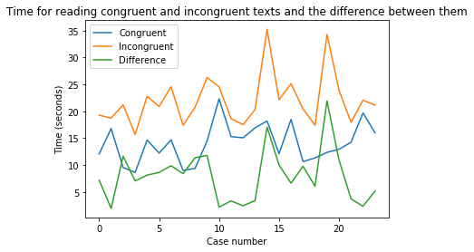

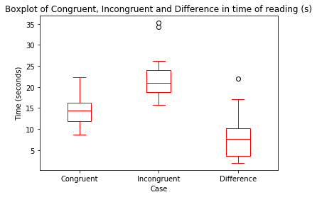

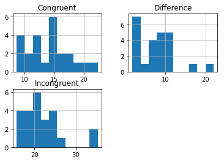

```python
# Line chart for Congruent, Incongruent, Difference
stroopdata.plot()
plt.title('Time for reading congruent and incongruent texts and the difference between them')
plt.ylabel('Time (seconds)')
plt.xlabel('Case number')

# Boxplot for Congruent, Incongruent, Difference
stroopdata.plot(kind='box', color='red',title="Boxplot of Congruent, Incongruent and Difference in time of reading (s)")
plt.ylabel('Time (seconds)')
plt.xlabel('Case')

# Histograms Congruent, Incongruent, Difference
stroopdata.hist()
```

The plots show that the incongruence shows a higher variability in time taken to name the colors and that the average in time taken is also higher than in the congruent situations.

(5) Now, perform the statistical test and report your results. What is your confidence level or Type I error associated with your test? What is your conclusion regarding the hypotheses you set up? Did the results match up with your expectations? Hint: Think about what is being measured on each individual, and what statistic best captures how an individual reacts in each environment.

```python
# Perform the statistical test here
from scipy import stats
sample_size= 23
stats.t.ppf(0.975, sample_size)

# Calculates the T-test on TWO RELATED samples of scores, a and b.
t,p_value=stats.ttest_rel(stroopdata['Congruent'], stroopdata['Incongruent'])
print("t_calculated = "+str(t))
print("P value = "+str(p_value))
```

```
t_calculated = -8.020706944109957
P value = 4.103000585711178e-08
```

The results show that t_calculed of -8.02 is much lower than the t_critical established at question 2 (t_critical=-2.5). Thus, the t_calculated is in the critical region and the NULL hypothesis(H0) is rejected. This means that the difference in time to name the colors is statistically different in the case of congruence versus incongruence between ink color and word.

(6) Optional: What do you think is responsible for the effects observed? Can you think of an alternative or similar task that would result in a similar effect? Some research about the problem will be helpful for thinking about these two questions!

The interference between the different information (what the words say and the color of the words) brain receives causes a problem. There are two theories that may explain the Stroop effect:  
-Speed of Processing Theory: the interference occurs because words are read faster than colors are named. -Selective Attention Theory: the interference occurs because naming colors requires more attention than reading words.  
A similar task with a similar effect would be the time it takes to complete an Udacity project at home in a quiet environment versus the time it takes for the similar task to complete in a busy cafe.

Refferences:  
https://www.statisticssolutions.com/manova-analysis-paired-sample-t-test/  
https://faculty.washington.edu/chudler/words.html  
https://www.cognifit.com/science/cognitive-skills/processing-speed